# Graduate Fellows Handbook

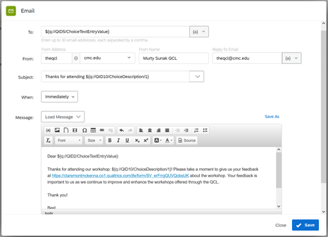

Step 5:

- Exit

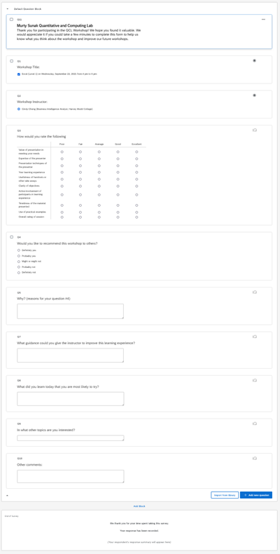

Step 6:

- Change workflow link
  - Make sure Dr. Park is getting an email sent to him

[figure not shown]

[figure not shown]

Step 7:

- Click Publish

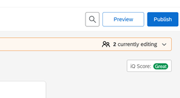

Step 8:

- Copy link to use for Bit.ly later and hit publish
  - If you forget to get here, you can still get it when you make QR code

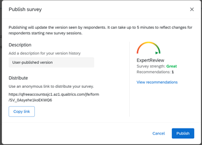

Step 9:

- Barcode for Word doc
  - Anonymous link will give you the link of the survey again to put into Bit.ly
  - Download QR code for word doc use

[figure not shown]

**Bit.ly**

[figure not shown]

Bit.ly

Step 1:

- Copy and paste the shorten link into word doc

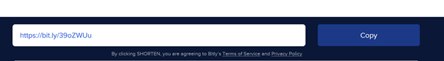

Step 2:

- Once you create a registration form on localist, would you please create bit.ly short cut and let me know? Do you know how to create a bit.ly URL shortcut?
  - created shortcuts with some naming convention she made for herself.
    - e.g., http://bit.ly/su2021-05-excel-L2-reg
    - e.g., https://bit.ly/fa2021-excel-1020

**Flyer Word doc**

- Change to fit workshop
  - Title
  - Date & Time
  - Instructor
  - QR Code from Qualtrics
  - Shorten link from Bit.ly

[figure not shown]

**Emails (to be written)**

**Reminder Email**

- Send out a reminder email.
- Add
  - Virtual Work info: Zoom invitation link (just in case)
  - In-Person Info:
  - Anything instructor wants to relay
- Example 1

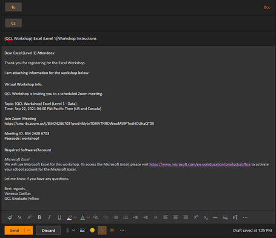

- Example 2

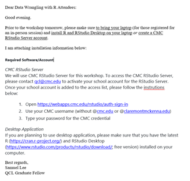

- Example 3

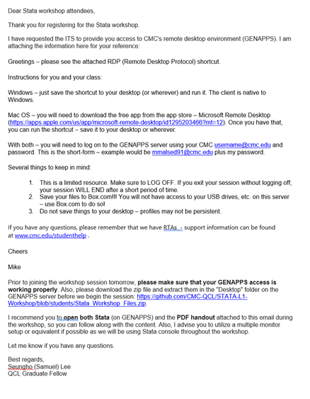

- Example 4

Dear MATLAB (Level 1 – Coding+Computing) Attendees:

Thank you for registering for the MATLAB (Level 1 – Coding+Computing) Workshop.

Getting Equipped with MATLAB (Level 1 – Coding+Computing)

Instructor: Bhaven Mistry (Assistant Director of the QCL)

Summary:  
Want to learn to program, but don’t know where to start or what to install? MATLAB is a numerical computing language and environment that is surprisingly easy to use. Typically used by engineers and scientists, you can think of it as a very powerful, customizable calculator. But, interestingly, it’s this very characteristic that makes MATLAB an ideal language for programming beginners, even if you’re not mathematically inclined. In this workshop, we will step you through the basics of programming using the MATLAB coding environment. We will start by getting familiar with the software, learning the basics of variable assignment and manipulation, writing our own functions, and exploring some applications. If you’re completely new to programming, learning the fundamentals with MATLAB first is a great way to springboard into other languages. Alternatively, if you have some experience with programming, but have always wanted to learn what MATLAB is used for, this could be a good way to get your feet wet.

Pre-requisites:  
Internet Use: Introductory level (search, log-in, navigation of websites, etc.) Software: Attendees are asked to have MATLAB on their computers for the workshop. MATLAB is available for CMC students and faculty at https://www.cmc.edu/information-technology/academic-software

Location:  
Online (Attendees will receive the Zoom meeting information after registration)

Participants:

Open to all CMC Students, Faculty and Staff

I am attaching information for the workshop below:  
QCL Workshop is inviting you to a scheduled Zoom meeting.

Topic: [QCL Workshop] Get Equipped with MATLAB

Time: Sep 29, 2021 03:00 PM Pacific Time (US and Canada)

Join Zoom Meeting

https://cmc-its.zoom.us/j/83773547610?pwd=Y2loa3VoWnQvWFQxUDg1V0xIbHBNdz09

Meeting ID: 837 7354 7610

Passcode: workshop!

Required Software/Account

https://www.cmc.edu/information-technology/academic-software

Let me know if you have any questions.

Best regards,  
Vanessa Casillas  
QCL Graduate Fellow

**Attendees Emails**

- Go to Localist and click on event

[figure not shown]

- Click on View Confirmed Tickets

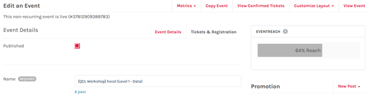

- Click Export CSV

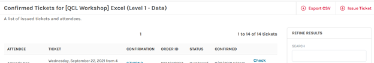

- Go to email and download the CSV

[figure not shown]

- Open CSV and copy emails into your reminder email

#### Day of workshop

**Moderator checklist**

- Morning of
  - Paste Zoom info in QCL Workshop – Workshop Control Booth chat in Teams
  - Send out reminders if you haven’t already
- Show up 30 minutes before workshop
  - Print out flyers
    - Put on tables where the attendees will sit
  - Log into Zoom (workshops)
    - Start 30 minutes before
    - Check audio and video
    - Make Instructor co-host
    - Test runs with instructor
  - Get shorten links from bit.ly ready
  - Set-up camera
  - Put the spotlight on workshop video feed
  - Make sure the instructor is screensharing
- Time of the workshop
  - Welcome everyone: (change when necessary for only virtual or only in person workshops)
    - Welcome to the QCL! Today’s workshop is (name of event) instructed by (name of instructor. My name is (your name) and I (as well as (other moderator)) will your moderators for today’s workshop. If you have any questions or concerns throughout the session, please write in chat for our virtual attendees or raise or have for our in-person attendees. Before we start, please make sure to sign in with either the QR code or the link provided. Lastly, this workshop will be recorded. Enjoy!
    - Link sign-in survey in chat and links for workshop from instructor Welcome! Please sign-in: https://bit.ly/3zDNzPj Link from instructor: https://github.com/CMC-QCL/Excel-L2-Workshop If you have any questions or concerns throughout the session, please write in chat @everyone. Thank you! Please sign-out: https://bit.ly/3EIOgdX
  - Click Record
    - Note: if on break, click pause not stop, we want the least number of files made
  - Check in attendees who attend on Localist
    - Cross check over Qualtrics to make sure that attendees take survey as well
  - Interrupt the instructor if an attendee online has a question or if the attendee in-person has not been seen raising their hand.
- End of workshop
  - Link Exit survey in chat
  - Thank everyone for coming
  - Clean up and back up
- Send email reminder if there is a low rate for surveys
- Send zoom meeting recordings to attendees that attended
  - Note: after every semester we dump recordings into a box file, before CMC does it

#### Day after workshop

**Qualtrics**

- Give “Collaborate” to instructor on surveys

**Zoom Recordings**

- Only provided to the attendees that showed up for the workshop
- Records are ready to send the next day after the workshop

[figure not shown]

**Ending email example**

Subject: Thank you for attending the (name of workshop) Workshop

Hello (name of workshop) attendees,

Thank you for attending the workshop.

I have provided the links for sign-in and sign-out:

Sign-in: (Link of survey)

Sign-out: (Link of survey)

Please make sure to complete the surveys, they count as your attendance. If you have already completed them, thank you.

(all pasted from zoom)

Note: records are only provided if you attend the workshop

Lastly, if there was any homework assigned for this workshop, please send all documents to: qcl@cmc.edu for grading.

Thank you, (your name) QCL Graduate Fellow

#### Workshop Issues

**New attendees after closed registration**

- Email to student for information: (Do not to ask for people’s gender for the new attendee’s emails as it is optional on our form.)

Subject: [QCL] Online Workshop on name (date at time) and name (date at time)  
[Bcc’d everyone else except QCL Fellows]

Hi (name of new attendee),

Would you like to register for both Excel 1 and Excel 2 sessions?

Also, are you able to provide me following information?  
1. Please enter your student ID # (Must be 8 characters). For all faculty/staff/non-Claremont Colleges person, please insert 00000000.  
2. Gender  
3. Are you a Freshman, Sophomore, Junior, Senior, Graduate Student, Faculty, Staff or Other?

Please note that we usually close registration 1 to 3 days prior (depending on the preparation needed to set up a working environment) to workshop events.

Best regards,  
QCL Graduate Fellow (put your name here)

Subject: [QCL Workshop] Name of workshop – Availability

Hi (name of new attendee),

I have input your information into Localist for the (name of workshop) workshop.

You should have received a Localist ticket by now.

Please let me know if you have any questions.

Best regards, QCL Graduate Fellow (put your name here)

- If you just input, the new attendee without information, send this email

Subject: [QCL Workshop] Name of workshop – Availability

Hi (name of new attendee),

I just received a message from Janna that you would like to register for the (name of workshop) workshop.

You should have received a Localist ticket by now.

Please let me know if you have any questions.

Best regards, QCL Graduate Fellow (put your name here)

- Note: We typically have 15 seats but wait list is 5

**Check attendee’s emails**

- Fix emails, sometimes they misspell their emails

#### h. Building a Workshop

**Pre-workshop requirements PDF**

- Make in program you would like to use (i.e., Powerpoint, ArcGis Stories)
- Make it into a PDF to send before workshop
- Downloading software How to for Mac and Windows
- License information
- Explain what to bring to workshop

**Files**

- Data files to import
  - Hand-on activities
- Other files of interest

#### i. Workshops Building

- In the past, the way we offer our workshop to specific institute like Lowe was that we (Cindy) worked with their admin or student leader to find good times for their fellows and RAs and offer a separate workshop(s) for them. I am thinking we would want to offer them a separate GIS workshop(s).

Who asked for QCL trainings:

brooke.bernal@claremontmckenna.edu (Rose Institute)  
brittany.bras@claremontmckenna.edu (Rose Institute)  
Kristin.Miller@ClaremontMcKenna.edu (Roberts Environment Center)  
npatel21@students.claremontmckenna.edu (Student Manager Rose Institute)  
jennifer.feitosa@claremontmckenna.edu (Psychology, asked for SPSS and Excel)

Who you can ask for QCL workshops:

Jeanine Finn jeanine.finn@claremont.edu (Unix Shell and Git)  
Brandon Bak brandonbak@gmail.com (Alteryx)  
Cindy Cheng cindy.cheng@cgu.edu (Power BI)  
Alfonso Landeros alanderos@ucla.edu (Julia)  
Aashita Kesarwani akesarwani@hmc.edu (ML)  
Brad McCauley bmccauley@hmc.edu (bash script)

SQL dataset used for Fall 2020 attached.

#### j. Zoom Recording Downloads

We are reaching out today with a friendly and important reminder to please transfer or delete your older Zoom cloud recordings within your Zoom account to help ensure that we can continue to provide this service to our faculty and staff without accruing additional storage expenses.

Our Zoom cloud recording storage currently has a shared quota of 1 terabyte for all users and about 1 gigabyte of storage per individual user. However, we now have several Zoom accounts that are way over the 1 gigabyte storage allotment. To collectively help save space, we recommend that all users download their Zoom recordings and store them in an alternate location, such as Box where much more storage space is available. Once you’ve stored the recordings in an alternate location, please make sure to go back and delete the recordings from your Zoom cloud storage.

Action Needed:

- If you use Zoom cloud recording – please follow the below instructions for offloading your recordings and then delete them off Zoom once transferred

*How to Download Your Zoom Cloud Recordings:*

1. Login to the Zoom.us web portal (https://zoom.us)
2. In the left-hand navigation menu, click Recordings (direct link: https://zoom.us/recording)
3. Click More next to a meeting recording and click Download

4. Click Download on the pop-up that appears

5. Click Allow if prompted for permission to Download multiple files.

6. Check your Downloads folder for your recording files (.m4a for audio and .mp4 for video)

Once downloaded, you can upload your files to your Box account (https://claremontmckenna.box.com). Box has a very large storage capacity per user and can be increased when necessary.

Once your files are on Box or stored somewhere safe off Zoom, you can share your files with others using the instructions outlined in the attached PDF guide called “Sharing Files in Box”.

Alternatively, if you’d like to use local recording instead with Zoom, we have attached guides for this as well. However, we only recommend this for non-critical events and for use outside of the classroom setting.

#### k. Qualtrics Make a Workflow

- Sign-in Survey

- Exit Survey